# Progetto_Meteo_Australia

**PROGETTO METEO AUSTRALIA**

Fase iniziale: preprocessing. Inizio con importare il dataset e ottenere semplici informazioni riguardo la dimensione e statistiche sulle colonne.

```python
import pandas as pd
import numpy as np
import matplotlib.pyplot as plt
import seaborn as sns

plt.style.use('seaborn-notebook')

df = pd.read_csv('weatherAUS.csv')
df.head(5)
```

|  | Date | Location | MinTemp | MaxTemp | Rainfall | Evaporation | Sunshine | WindGustDir | WindGustSpeed | WindDir9am | ... | Humidity3pm | Pressure9am | Pressure3pm | Cloud9am | Cloud3pm | Temp9am | Temp3pm | RainToday | RISK_MM | RainTomorrow |
| --- | --- | --- | --- | --- | --- | --- | --- | --- | --- | --- | --- | --- | --- | --- | --- | --- | --- | --- | --- | --- | --- |
| 0 | 2008-12-01 | Albury | 13.4 | 22.9 | 0.6 | NaN | NaN | W | 44.0 | W | ... | 22.0 | 1007.7 | 1007.1 | 8.0 | NaN | 16.9 | 21.8 | No | 0.0 | No |
| 1 | 2008-12-02 | Albury | 7.4 | 25.1 | 0.0 | NaN | NaN | WNW | 44.0 | NNW | ... | 25.0 | 1010.6 | 1007.8 | NaN | NaN | 17.2 | 24.3 | No | 0.0 | No |
| 2 | 2008-12-03 | Albury | 12.9 | 25.7 | 0.0 | NaN | NaN | WSW | 46.0 | W | ... | 30.0 | 1007.6 | 1008.7 | NaN | 2.0 | 21.0 | 23.2 | No | 0.0 | No |
| 3 | 2008-12-04 | Albury | 9.2 | 28.0 | 0.0 | NaN | NaN | NE | 24.0 | SE | ... | 16.0 | 1017.6 | 1012.8 | NaN | NaN | 18.1 | 26.5 | No | 1.0 | No |
| 4 | 2008-12-05 | Albury | 17.5 | 32.3 | 1.0 | NaN | NaN | W | 41.0 | ENE | ... | 33.0 | 1010.8 | 1006.0 | 7.0 | 8.0 | 17.8 | 29.7 | No | 0.2 | No |

5 rows × 24 columns

Controllo la dimensione del dataset, per capire con quante entry abbiamo a che fare.

```python
df.shape
```

```
(142193, 24)
```

Verifico quante entries sono presenti per ciascun attributo, così da verificare la presenza di valori nulli.

```python
df.info()
```

```
<class 'pandas.core.frame.DataFrame'>
RangeIndex: 142193 entries, 0 to 142192
Data columns (total 24 columns):
Date             142193 non-null object
Location         142193 non-null object
MinTemp          141556 non-null float64
MaxTemp          141871 non-null float64
Rainfall         140787 non-null float64
Evaporation      81350 non-null float64
Sunshine         74377 non-null float64
WindGustDir      132863 non-null object
WindGustSpeed    132923 non-null float64
WindDir9am       132180 non-null object
WindDir3pm       138415 non-null object
WindSpeed9am     140845 non-null float64
WindSpeed3pm     139563 non-null float64
Humidity9am      140419 non-null float64
Humidity3pm      138583 non-null float64
Pressure9am      128179 non-null float64
Pressure3pm      128212 non-null float64
Cloud9am         88536 non-null float64
Cloud3pm         85099 non-null float64
Temp9am          141289 non-null float64
Temp3pm          139467 non-null float64
RainToday        140787 non-null object
RISK_MM          142193 non-null float64
RainTomorrow     142193 non-null object
dtypes: float64(17), object(7)
memory usage: 26.0+ MB
```

Descrizione generale delle statistiche del dataset.

```python
df.describe()
```

|  | MinTemp | MaxTemp | Rainfall | Evaporation | Sunshine | WindGustSpeed | WindSpeed9am | WindSpeed3pm | Humidity9am | Humidity3pm | Pressure9am | Pressure3pm | Cloud9am | Cloud3pm | Temp9am | Temp3pm | RISK_MM |
| --- | --- | --- | --- | --- | --- | --- | --- | --- | --- | --- | --- | --- | --- | --- | --- | --- | --- |
| count | 141556.000000 | 141871.000000 | 140787.000000 | 81350.000000 | 74377.000000 | 132923.000000 | 140845.000000 | 139563.000000 | 140419.000000 | 138583.000000 | 128179.000000 | 128212.000000 | 88536.000000 | 85099.000000 | 141289.000000 | 139467.000000 | 142193.000000 |
| mean | 12.186400 | 23.226784 | 2.349974 | 5.469824 | 7.624853 | 39.984292 | 14.001988 | 18.637576 | 68.843810 | 51.482606 | 1017.653758 | 1015.258204 | 4.437189 | 4.503167 | 16.987509 | 21.687235 | 2.360682 |
| std | 6.403283 | 7.117618 | 8.465173 | 4.188537 | 3.781525 | 13.588801 | 8.893337 | 8.803345 | 19.051293 | 20.797772 | 7.105476 | 7.036677 | 2.887016 | 2.720633 | 6.492838 | 6.937594 | 8.477969 |
| min | -8.500000 | -4.800000 | 0.000000 | 0.000000 | 0.000000 | 6.000000 | 0.000000 | 0.000000 | 0.000000 | 0.000000 | 980.500000 | 977.100000 | 0.000000 | 0.000000 | -7.200000 | -5.400000 | 0.000000 |
| 25% | 7.600000 | 17.900000 | 0.000000 | 2.600000 | 4.900000 | 31.000000 | 7.000000 | 13.000000 | 57.000000 | 37.000000 | 1012.900000 | 1010.400000 | 1.000000 | 2.000000 | 12.300000 | 16.600000 | 0.000000 |
| 50% | 12.000000 | 22.600000 | 0.000000 | 4.800000 | 8.500000 | 39.000000 | 13.000000 | 19.000000 | 70.000000 | 52.000000 | 1017.600000 | 1015.200000 | 5.000000 | 5.000000 | 16.700000 | 21.100000 | 0.000000 |
| 75% | 16.800000 | 28.200000 | 0.800000 | 7.400000 | 10.600000 | 48.000000 | 19.000000 | 24.000000 | 83.000000 | 66.000000 | 1022.400000 | 1020.000000 | 7.000000 | 7.000000 | 21.600000 | 26.400000 | 0.800000 |
| max | 33.900000 | 48.100000 | 371.000000 | 145.000000 | 14.500000 | 135.000000 | 130.000000 | 87.000000 | 100.000000 | 100.000000 | 1041.000000 | 1039.600000 | 9.000000 | 9.000000 | 40.200000 | 46.700000 | 371.000000 |

Le statistiche di risk_MM sono quasi equivalenti a Rainfall, meglio verificare una loro possibile correlazione. Inoltre il 75% dei dati di rainfall è prossimo allo 0, potrebbe essere utile discretizzarlo. Prima di fare tutto questo, controllo le colonne con il maggior numero di valori nulli. Ovvero, verifico in percentuale quanti nan sono presenti nelle corrispondenti colonne.

```python
pd.set_option("max_columns",24)
pd.DataFrame(df.isnull().sum()/df.shape[0]).T
```

|  | Date | Location | MinTemp | MaxTemp | Rainfall | Evaporation | Sunshine | WindGustDir | WindGustSpeed | WindDir9am | WindDir3pm | WindSpeed9am | WindSpeed3pm | Humidity9am | Humidity3pm | Pressure9am | Pressure3pm | Cloud9am | Cloud3pm | Temp9am | Temp3pm | RainToday | RISK_MM | RainTomorrow |
| --- | --- | --- | --- | --- | --- | --- | --- | --- | --- | --- | --- | --- | --- | --- | --- | --- | --- | --- | --- | --- | --- | --- | --- | --- |
| 0 | 0.0 | 0.0 | 0.00448 | 0.002265 | 0.009888 | 0.42789 | 0.476929 | 0.065615 | 0.065193 | 0.070418 | 0.02657 | 0.00948 | 0.018496 | 0.012476 | 0.025388 | 0.098556 | 0.098324 | 0.377353 | 0.401525 | 0.006358 | 0.019171 | 0.009888 | 0.0 | 0.0 |

Evaporation e sunshine presentano troppi nan, meglio eliminarli per evitare di falsare le future analisi. Droperò anche le righe che presentano tutti valori null.

```python
df.dropna(axis = 0, how = 'all')
df = df.drop('Evaporation', axis = 1)
df = df.drop('Sunshine', axis = 1)
df.shape
```

```
(142193, 22)
```

Adesso verifico la correlazione tra Rainfall e tutti gli altri attributi. In oarticolare, verifico, come già detto in orecedenza, se è presente una forte correlazione con Risk_MM.

```python
mtxcorr = df.corr()
mtxcorr["Rainfall"].sort_values(ascending=False)
```

```
Rainfall         1.000000
RISK_MM          0.308557
Humidity3pm      0.255312
Humidity9am      0.223725
Cloud9am         0.198195
Cloud3pm         0.171993
WindGustSpeed    0.133497
MinTemp          0.104255
WindSpeed9am     0.086816
WindSpeed3pm     0.057759
Temp9am          0.011477
MaxTemp         -0.074839
Temp3pm         -0.079178
Pressure3pm     -0.126728
Pressure9am     -0.168085
Name: Rainfall, dtype: float64
```

Correlazione bassa, però i valori differiscono di poco; considerando le statistiche quasi equivalenti (cambia la media ma di poco). Quindi ho deciso di dropparla, considerando che anche la descrizione di Kaggle consiglia di farlo; essendo una collona aggiunta quando hanno messo insieme i dati, e non è chiaro come l'abbiano ricavata. Meglio non rischiare ed eliminiamola.

```python
df=df.drop('RISK_MM',axis=1)
df.shape
```

```
(142193, 21)
```

Altri due attributi presentano un'elevata percentuale di valori nulli, 40% circa ,ma sono solamente cloud3pm e cloud9am. Leggendo la descrizione su kaggle il valore delle nuvole è rappresentato in scale okta, nella quale nan indica *nil significant cloud*, ovvero che ci sono le nuvole, ma la loro presenza non è significativa. Quindi nel nostro caso, una presenza non significativa di nuvole assume lo stesso significato di 0 (niente nuvole), nel nostro caso della classificazione. Ipotizziamo che nan non sia un campionamento non effetuato, ma un valore della scala okta come detto poc'anzi. Se per caso la nostra ipotesi si dovesse rivelare errata, ovvero il valore della classificazione dovesse risultare non soddisfacente, provvederemo ad eliminare questi attributi e verificheremo se la classificazione avrà dei miglioramenti oppure no.

```python
df.Cloud3pm.unique()
```

```
array([nan,  2.,  8.,  7.,  1.,  5.,  4.,  6.,  3.,  0.,  9.])
```

```python
df.Cloud9am.unique()
```

```
array([ 8., nan,  7.,  1.,  0.,  5.,  4.,  2.,  6.,  3.,  9.])
```

I valori assunti dalle due colonne rispecchiano i valori della scala okta. Prima di rimpiazzare i nan con 0, vorrei analizzare i casi in cui è presente il numero 9. Perchè il 9 indica cielo oscurato da nebbia o altri fenomeni atmosferici. Quindi questo presenta delle anomalie atmosferiche, che potrebbero essere delle anomalie anche nel nostro dataset o dei semplici utliers.

```python
df[df['Cloud3pm']==9]
```

|  | Date | Location | MinTemp | MaxTemp | Rainfall | WindGustDir | WindGustSpeed | WindDir9am | WindDir3pm | WindSpeed9am | WindSpeed3pm | Humidity9am | Humidity3pm | Pressure9am | Pressure3pm | Cloud9am | Cloud3pm | Temp9am | Temp3pm | RainToday | RainTomorrow |
| --- | --- | --- | --- | --- | --- | --- | --- | --- | --- | --- | --- | --- | --- | --- | --- | --- | --- | --- | --- | --- | --- |
| 104342 | 2012-11-02 | Woomera | 10.6 | 24.6 | 0.2 | SSE | 39.0 | SE | ESE | 26.0 | 17.0 | 45.0 | 13.0 | 1019.0 | 1015.2 | 6.0 | 9.0 | 14.8 | 23.7 | No | No |

```python
df[df['Cloud9am']==9]
```

|  | Date | Location | MinTemp | MaxTemp | Rainfall | WindGustDir | WindGustSpeed | WindDir9am | WindDir3pm | WindSpeed9am | WindSpeed3pm | Humidity9am | Humidity3pm | Pressure9am | Pressure3pm | Cloud9am | Cloud3pm | Temp9am | Temp3pm | RainToday | RainTomorrow |
| --- | --- | --- | --- | --- | --- | --- | --- | --- | --- | --- | --- | --- | --- | --- | --- | --- | --- | --- | --- | --- | --- |
| 30097 | 2009-09-23 | Sydney | 17.0 | 21.8 | 4.4 | NaN | NaN | W | W | 30.0 | 37.0 | 40.0 | 36.0 | 996.8 | 997.8 | 9.0 | 3.0 | 17.3 | 20.9 | Yes | No |
| 45981 | 2012-05-27 | Canberra | 0.6 | 14.5 | 0.0 | SW | 30.0 | NNW | SSW | 4.0 | 9.0 | 99.0 | 41.0 | 1022.4 | 1020.7 | 9.0 | NaN | 4.4 | 14.2 | No | No |

Potrebbero essere degli outliers però il valore 9 è presente solo a uno dei due degli attributi e mai in contemporanea, quindi probabilmente non falsificano le analisi.C'è addirittura una correlazione, che quando è presente il 9 è sempre NO l'etichetta della piogga. Anche se non è significativa come correlazione dato che sono solo 3 casi.

```python
#riempio i nan con 0
df['Cloud3pm'].fillna(0,inplace=True)
df['Cloud9am'].fillna(0,inplace=True)
df.info()
```

```
<class 'pandas.core.frame.DataFrame'>
RangeIndex: 142193 entries, 0 to 142192
Data columns (total 21 columns):
Date             142193 non-null object
Location         142193 non-null object
MinTemp          141556 non-null float64
MaxTemp          141871 non-null float64
Rainfall         140787 non-null float64
WindGustDir      132863 non-null object
WindGustSpeed    132923 non-null float64
WindDir9am       132180 non-null object
WindDir3pm       138415 non-null object
WindSpeed9am     140845 non-null float64
WindSpeed3pm     139563 non-null float64
Humidity9am      140419 non-null float64
Humidity3pm      138583 non-null float64
Pressure9am      128179 non-null float64
Pressure3pm      128212 non-null float64
Cloud9am         142193 non-null float64
Cloud3pm         142193 non-null float64
Temp9am          141289 non-null float64
Temp3pm          139467 non-null float64
RainToday        140787 non-null object
RainTomorrow     142193 non-null object
dtypes: float64(14), object(7)
memory usage: 22.8+ MB
```

Le due colonne riguardanti le nuvole non presentano più valori nulli. 142193 valori non-null come le entries del dataset.

Adesso effettuo delle analisi statistiche, riguradanti la probabilità di pioggia quando è presente un determinato valore degli attributi Cloud9am e Cloud3pm.

```python
# vediamo che succede quando c'è presenza di nuvole
df_Cloud = df.groupby(['Cloud9am', 'RainTomorrow'])[['Date']].count()
df_Cloud = df_Cloud.rename({'Date': 'count'}, axis=1)
df_Cloud['prob'] = df_Cloud['count'] / df.groupby('Cloud9am').count()['RainTomorrow']
df_Cloud
```

| Cloud9am | RainTomorrow | count | prob |
| --- | --- | --- | --- |
| 0.0 | No | 50756 | 0.815436 |
|  | Yes | 11488 | 0.184564 |
| 1.0 | No | 14259 | 0.916506 |
|  | Yes | 1299 | 0.083494 |
| 2.0 | No | 5535 | 0.859205 |
|  | Yes | 907 | 0.140795 |
| 3.0 | No | 4872 | 0.832251 |
|  | Yes | 982 | 0.167749 |
| 4.0 | No | 3495 | 0.799223 |
|  | Yes | 878 | 0.200777 |
| 5.0 | No | 4281 | 0.776951 |
|  | Yes | 1229 | 0.223049 |
| 6.0 | No | 5946 | 0.736620 |
|  | Yes | 2126 | 0.263380 |
| 7.0 | No | 13327 | 0.674819 |
|  | Yes | 6422 | 0.325181 |
| 8.0 | No | 7843 | 0.545069 |
|  | Yes | 6546 | 0.454931 |
| 9.0 | No | 2 | 1.000000 |

Non è molto correlato con la pioggia, l'unico dato significativo l'abbiamo con 8, che indica pioggia quasi al 50%; già con 7 piove al 32% e man mano che diminuisce il valore diminuisce sempre di più la probabilità di pioggia.

```python
df_Cloud3 = df.groupby(['Cloud3pm', 'RainTomorrow'])[['Date']].count()
df_Cloud3 = df_Cloud3.rename({'Date': 'count'}, axis=1)
df_Cloud3['prob'] = df_Cloud3['count'] / df.groupby('Cloud3pm').count()['RainTomorrow']
df_Cloud3
```

| Cloud3pm | RainTomorrow | count | prob |
| --- | --- | --- | --- |
| 0.0 | No | 50426 | 0.812654 |
|  | Yes | 11625 | 0.187346 |
| 1.0 | No | 13995 | 0.943886 |
|  | Yes | 832 | 0.056114 |
| 2.0 | No | 6496 | 0.908150 |
|  | Yes | 657 | 0.091850 |
| 3.0 | No | 5950 | 0.870392 |
|  | Yes | 886 | 0.129608 |
| 4.0 | No | 4318 | 0.821850 |
|  | Yes | 936 | 0.178150 |
| 5.0 | No | 5390 | 0.799347 |
|  | Yes | 1353 | 0.200653 |
| 6.0 | No | 6621 | 0.746533 |
|  | Yes | 2248 | 0.253467 |
| 7.0 | No | 11564 | 0.640594 |
|  | Yes | 6488 | 0.359406 |
| 8.0 | No | 5555 | 0.447731 |
|  | Yes | 6852 | 0.552269 |
| 9.0 | No | 1 | 1.000000 |

Statistiche simili rispetto a prima anche con l'attributo Cloud3pm, anche se la probabilità di pioggià è leggermente più alta.

```python
df['Cloud3pm']= ((df.Cloud3pm*8)+(df.Cloud9am*2))//10  #calcolo pesato 80% di importanza alle 3 del pomeriggio rispetto alle 8 del mattino
df['Cloud3pm']
```

```
0         1.0
1         0.0
2         1.0
3         0.0
4         7.0
5         0.0
6         0.0
7         0.0
8         0.0
9         0.0
10        0.0
11        8.0
12        8.0
13        5.0
14        0.0
```

[output cut: 47 more lines]

```python
df=df.rename(columns={'Cloud3pm':'Cloud'})
df=df.drop('Cloud9am',axis=1)
df.head(5)
```

|  | Date | Location | MinTemp | MaxTemp | Rainfall | WindGustDir | WindGustSpeed | WindDir9am | WindDir3pm | WindSpeed9am | WindSpeed3pm | Humidity9am | Humidity3pm | Pressure9am | Pressure3pm | Cloud | Temp9am | Temp3pm | RainToday | RainTomorrow |
| --- | --- | --- | --- | --- | --- | --- | --- | --- | --- | --- | --- | --- | --- | --- | --- | --- | --- | --- | --- | --- |
| 0 | 2008-12-01 | Albury | 13.4 | 22.9 | 0.6 | W | 44.0 | W | WNW | 20.0 | 24.0 | 71.0 | 22.0 | 1007.7 | 1007.1 | 1.0 | 16.9 | 21.8 | No | No |
| 1 | 2008-12-02 | Albury | 7.4 | 25.1 | 0.0 | WNW | 44.0 | NNW | WSW | 4.0 | 22.0 | 44.0 | 25.0 | 1010.6 | 1007.8 | 0.0 | 17.2 | 24.3 | No | No |
| 2 | 2008-12-03 | Albury | 12.9 | 25.7 | 0.0 | WSW | 46.0 | W | WSW | 19.0 | 26.0 | 38.0 | 30.0 | 1007.6 | 1008.7 | 1.0 | 21.0 | 23.2 | No | No |
| 3 | 2008-12-04 | Albury | 9.2 | 28.0 | 0.0 | NE | 24.0 | SE | E | 11.0 | 9.0 | 45.0 | 16.0 | 1017.6 | 1012.8 | 0.0 | 18.1 | 26.5 | No | No |
| 4 | 2008-12-05 | Albury | 17.5 | 32.3 | 1.0 | W | 41.0 | ENE | NW | 7.0 | 20.0 | 82.0 | 33.0 | 1010.8 | 1006.0 | 7.0 | 17.8 | 29.7 | No | No |

Sono riuscito a mettere solo una colonna. Ora verifico se la correlazione è rimasta equivalente.

```python
# vediamo che succede quando c'è presenza di nuvole
df_Cloud = df.groupby(['Cloud', 'RainTomorrow'])[['Date']].count()
df_Cloud = df_Cloud.rename({'Date': 'count'}, axis=1)
df_Cloud['prob'] = df_Cloud['count'] / df.groupby('Cloud').count()['RainTomorrow']
df_Cloud
```

| Cloud | RainTomorrow | count | prob |
| --- | --- | --- | --- |
| 0.0 | No | 50738 | 0.821841 |
|  | Yes | 10999 | 0.178159 |
| 1.0 | No | 14255 | 0.912554 |
|  | Yes | 1366 | 0.087446 |
| 2.0 | No | 7601 | 0.899314 |
|  | Yes | 851 | 0.100686 |
| 3.0 | No | 6059 | 0.860409 |
|  | Yes | 983 | 0.139591 |
| 4.0 | No | 5532 | 0.809127 |
|  | Yes | 1305 | 0.190873 |
| 5.0 | No | 6908 | 0.775048 |
|  | Yes | 2005 | 0.224952 |
| 6.0 | No | 8188 | 0.680915 |
|  | Yes | 3837 | 0.319085 |
| 7.0 | No | 8502 | 0.560781 |
|  | Yes | 6659 | 0.439219 |
| 8.0 | No | 2533 | 0.395472 |
|  | Yes | 3872 | 0.604528 |

Correlazione rimasta equivalente.

Ora mi occupo di un'altra colonna che presenta un basso numero di valori nulli, ma potrebbe rivelarsi un attributo fondamentale. Sto parlando della colonna RainToday, alla quale è possibile sopperire alla mancanza di valori, semplicemente andando a inserire nelle celle vuote il valore della colonna di RainTomorrow del giorno precedente. Ovviamente ho controllato che il primo dato, ovvero il primo giorno, non avesse valori nulli, perchè in quel caso sarebbe impossibile sostituire il valore non avendo un giorno precedente da controllare.

```python
#sostituisco i valori null di rain today controllando il valore di RainTomorrow precedente
index=df.loc[df['RainToday'].isnull(),:].index
df['RainToday'][index]=df.loc[index-1,'RainTomorrow']
df.info()
```

```
<class 'pandas.core.frame.DataFrame'>
RangeIndex: 142193 entries, 0 to 142192
Data columns (total 20 columns):
Date             142193 non-null object
Location         142193 non-null object
MinTemp          141556 non-null float64
MaxTemp          141871 non-null float64
Rainfall         140787 non-null float64
WindGustDir      132863 non-null object
WindGustSpeed    132923 non-null float64
WindDir9am       132180 non-null object
WindDir3pm       138415 non-null object
WindSpeed9am     140845 non-null float64
WindSpeed3pm     139563 non-null float64
Humidity9am      140419 non-null float64
Humidity3pm      138583 non-null float64
Pressure9am      128179 non-null float64
Pressure3pm      128212 non-null float64
Cloud            142193 non-null float64
Temp9am          141289 non-null float64
Temp3pm          139467 non-null float64
RainToday        142193 non-null object
RainTomorrow     142193 non-null object
dtypes: float64(13), object(7)
memory usage: 21.7+ MB
```

```
/home/bobo/anaconda3/lib/python3.7/site-packages/ipykernel_launcher.py:3: SettingWithCopyWarning:
A value is trying to be set on a copy of a slice from a DataFrame

See the caveats in the documentation: http://pandas.pydata.org/pandas-docs/stable/indexing.html#indexing-view-versus-copy
  This is separate from the ipykernel package so we can avoid doing imports until
```

**Da warning ma i valori li sostituisce**

Discretizzo i valori di Rain today e rain tomorrow in 1 e 0, così questi attributi passano da nominali a categorici. Effettuo questo cambio, perchè il calcolatore e gli algoritmi non lavorano bene con gli attributi nominali.

```python
df['RainTomorrow'].replace({'Yes': 1,'No': 0},inplace=True)
df['RainToday'].replace({'Yes': 1,'No': 0},inplace=True)
df.head()
```

|  | Date | Location | MinTemp | MaxTemp | Rainfall | WindGustDir | WindGustSpeed | WindDir9am | WindDir3pm | WindSpeed9am | WindSpeed3pm | Humidity9am | Humidity3pm | Pressure9am | Pressure3pm | Cloud | Temp9am | Temp3pm | RainToday | RainTomorrow |
| --- | --- | --- | --- | --- | --- | --- | --- | --- | --- | --- | --- | --- | --- | --- | --- | --- | --- | --- | --- | --- |
| 0 | 2008-12-01 | Albury | 13.4 | 22.9 | 0.6 | W | 44.0 | W | WNW | 20.0 | 24.0 | 71.0 | 22.0 | 1007.7 | 1007.1 | 1.0 | 16.9 | 21.8 | 0 | 0 |
| 1 | 2008-12-02 | Albury | 7.4 | 25.1 | 0.0 | WNW | 44.0 | NNW | WSW | 4.0 | 22.0 | 44.0 | 25.0 | 1010.6 | 1007.8 | 0.0 | 17.2 | 24.3 | 0 | 0 |
| 2 | 2008-12-03 | Albury | 12.9 | 25.7 | 0.0 | WSW | 46.0 | W | WSW | 19.0 | 26.0 | 38.0 | 30.0 | 1007.6 | 1008.7 | 1.0 | 21.0 | 23.2 | 0 | 0 |
| 3 | 2008-12-04 | Albury | 9.2 | 28.0 | 0.0 | NE | 24.0 | SE | E | 11.0 | 9.0 | 45.0 | 16.0 | 1017.6 | 1012.8 | 0.0 | 18.1 | 26.5 | 0 | 0 |
| 4 | 2008-12-05 | Albury | 17.5 | 32.3 | 1.0 | W | 41.0 | ENE | NW | 7.0 | 20.0 | 82.0 | 33.0 | 1010.8 | 1006.0 | 7.0 | 17.8 | 29.7 | 0 | 0 |

Controlliamo la relazione tra raintoday e rain tomorrow. Se per caso la pioggia del giorno corrente, aumenta la probabilità di pioggia del giorno seguente.

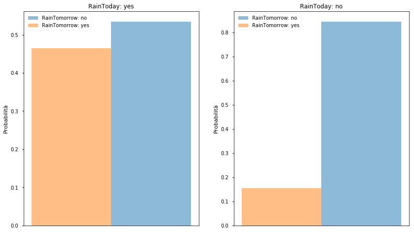

```python
df_today = df.groupby(['RainToday', 'RainTomorrow'])[['Date']].count()
df_today = df_today.rename({'Date': 'count'}, axis=1)
df_today['prob'] = df_today['count'] / df.groupby('RainToday').count()['RainTomorrow']

rain = df_today.loc[1]
no_rain= df_today.loc[0]
fig, axes = plt.subplots(1,2)
axes[0].bar(1,rain.loc[0]['prob'], label='RainTomorrow: no',align='edge',width=0.6,alpha=0.5)
axes[0].bar(1,rain.loc[1]['prob'], label='RainTomorrow: yes', align='edge',width=-0.6,alpha=0.5)

axes[1].bar(1,no_rain.loc[0]['prob'], label='RainTomorrow: no', align='edge',width=0.6,alpha=0.5)
axes[1].bar(1,no_rain.loc[1]['prob'], label='RainTomorrow: yes', align='edge',width=-0.6,alpha=0.5)

axes[0].set_title('RainToday: yes')
axes[1].set_title('RainToday: no')

axes[0].set_ylabel('Probabilità')
axes[1].set_ylabel('Probabilità')


axes[0].set_xticks([])
axes[1].set_xticks([])

axes[0].legend()
axes[1].legend()

fig.set_size_inches(14, 8)
plt.show()
```

RainToday influisce molto rain tomorrow nel caso in cui non piove, con 80% di probabilità che non piove nemmeno il giorno seguente.Se piove, il giorno seguente avremo una probabilità del 45% che piova. Influisce più di quanto pensassi.

Verifico la correlazione tra *TUTTI* gli attributi. Così verifico se qualche attributo è la combinazione di altri. Prima plotto i grafici e poi per casi specifici li verifico uno ad uno.

Controllo per primo la matrice di correlazione per tutti gli attributi. Molto probabilmente non si capirà molto, infatti dopo la vedo per singoli attributi.

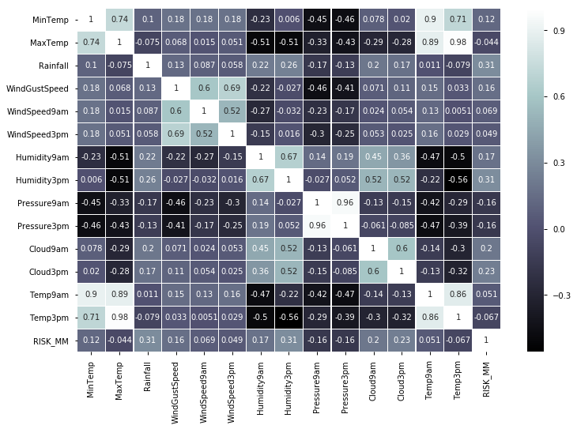

```python
plt.figure(figsize=(12,8))
sns.heatmap(mtxcorr,annot=True,cmap='bone',linewidths=0.25)
```

Già da questa matrice si nota la correlazione tra gli attributi che operano sugli stessi settori. Ad esempio notiamo la forte correlazione tra gli attributi che riguardano la temperatura, correlazione del 90% per alcuni di essi. La correlazione tra gli attributi della pressione, 96% di correlazione, e così via. Per una maggiore chiarezza verifico la correlazione degli attributi che rappresentano le stesse grandezze fisiche, tramite delle scatter matrix.

**N.B. Non è presente una scatter matrix tra tutte le possibili coppie di attributi, dato che la macchina non riesce a computarla, crasha spesso se provo a farla di tutti.**

Per primo controllo le ralzioni tra gli attributi riguardanti la tamperatura.

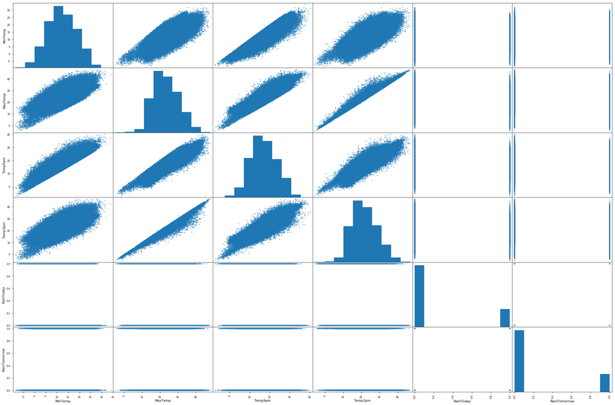

```python
from pandas.plotting import scatter_matrix


attributes = ['MinTemp','MaxTemp','Temp9am','Temp3pm','RainToday','RainTomorrow']

scatter_matrix(df[attributes], figsize=(36,24))
plt.show()
```

```python
df=df.drop("Temp3pm",axis=1)
df=df.drop("Temp9am",axis=1)
df.shape
```

```
(142193, 18)
```

Adesso controllo gli attributi adibiti all'umidità.

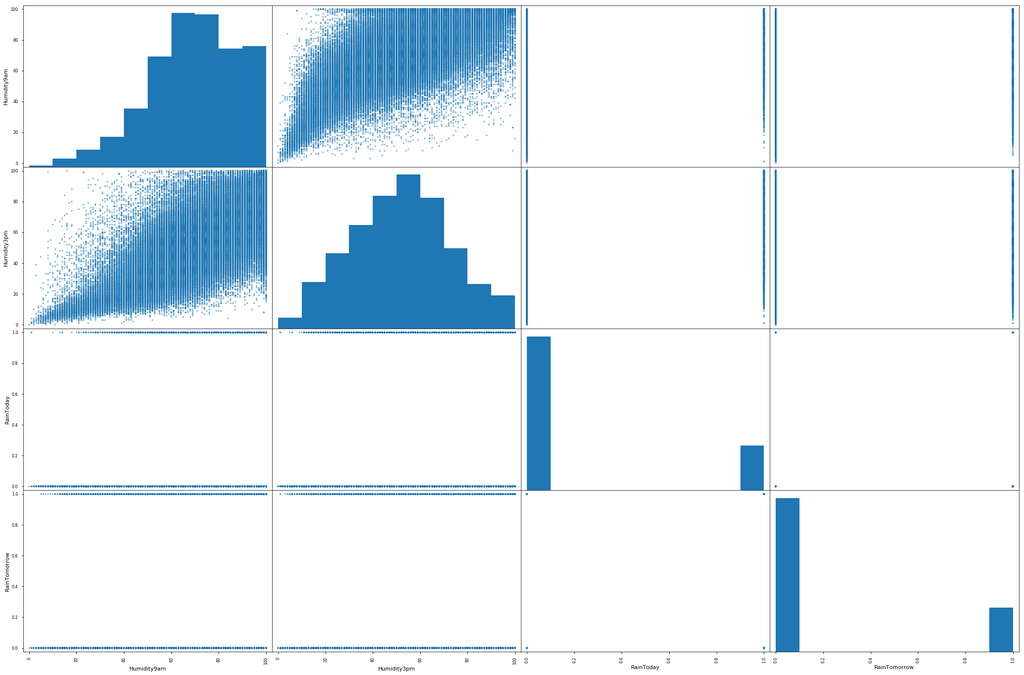

```python
attributes = ['Humidity9am','Humidity3pm','RainToday','RainTomorrow']

scatter_matrix(df[attributes], figsize=(36,24))
plt.show()
```

Forte correlazione tra le due

```python
mtxcorr = df.corr()
mtxcorr["Humidity3pm"].sort_values(ascending=False)
```

```
Humidity3pm      1.000000
Humidity9am      0.667388
RainTomorrow     0.446160
RainToday        0.376340
Cloud            0.315038
Rainfall         0.255312
Pressure3pm      0.051840
WindSpeed3pm     0.015903
MinTemp          0.005999
WindGustSpeed   -0.026663
Pressure9am     -0.027449
WindSpeed9am    -0.031607
MaxTemp         -0.509270
Name: Humidity3pm, dtype: float64
```

Anche in questo caso decido di unire le due colonne in una. Anche questa volta effettuo una media pesata dando più importanza all'attributo Humidity3pm, in quanto è una rilevazione che temporalmente è più vicina al giorno seguente, rispetto a quella effettuata alle 9 della mattina.

```python
df['Humidity3pm']= (df.Humidity3pm*8+df.Humidity9am*2)/10
df=df.rename(columns={'Humidity3pm':'Humidity'})
df=df.drop('Humidity9am',axis=1)

#controllo se la correlazione con rain tomorrow è rimasta uguale

mtxcorr = df.corr()
mtxcorr["Humidity"].sort_values(ascending=False)
```

```
Humidity         1.000000
RainTomorrow     0.433219
RainToday        0.391869
Cloud            0.308544
Rainfall         0.262618
Pressure3pm      0.081957
Pressure9am      0.004696
WindSpeed3pm    -0.014252
MinTemp         -0.039487
WindGustSpeed   -0.066629
WindSpeed9am    -0.081256
MaxTemp         -0.536164
Name: Humidity, dtype: float64
```

Adesso verifico la pressione.

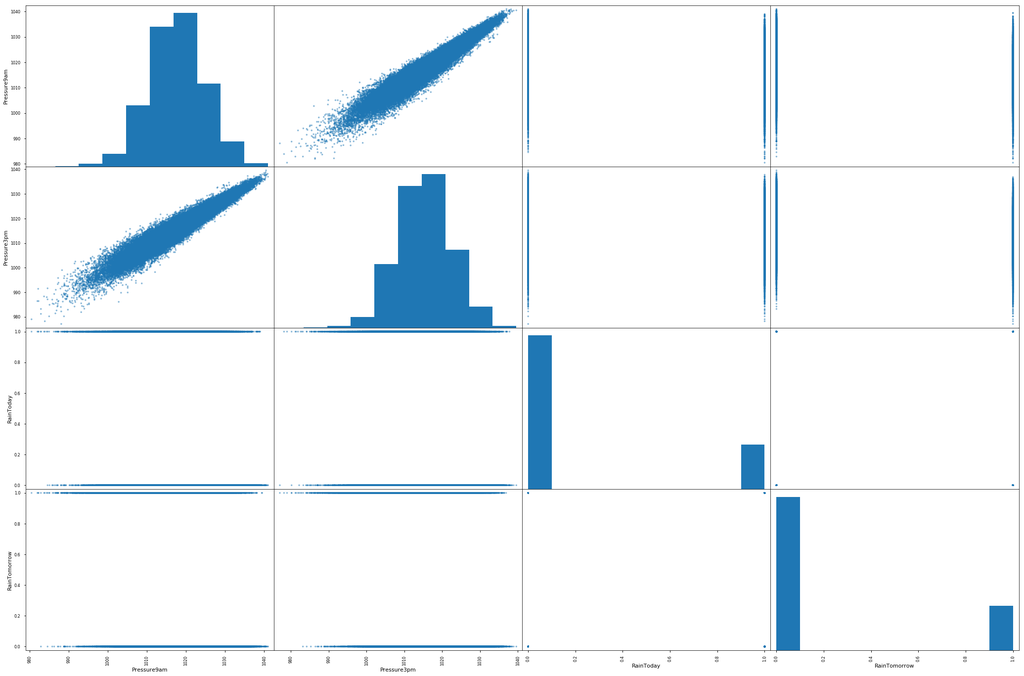

```python
attributes = ['Pressure9am','Pressure3pm','RainToday','RainTomorrow']

scatter_matrix(df[attributes], figsize=(36,24))
plt.show()
```

Anche in questo caso forte correlazione tra le due colonne.

```python
mtxcorr = df.corr()
mtxcorr["Pressure3pm"].sort_values(ascending=False)
```

```
Pressure3pm      1.000000
Pressure9am      0.961348
Humidity         0.081957
Cloud           -0.085609
RainToday       -0.104676
Rainfall        -0.126728
WindSpeed9am    -0.174916
RainTomorrow    -0.226031
WindSpeed3pm    -0.254988
WindGustSpeed   -0.412922
MaxTemp         -0.427279
MinTemp         -0.461623
Name: Pressure3pm, dtype: float64
```

Attributi quasi equivalenti, per evitare questa ridondanza li unisco in una sola colonna effettuando la media aritmetica dato che i due valori sono quasi uguali

```python
df['Pressure3pm']= (df.Pressure3pm+df.Pressure9am)/2
df=df.rename(columns={'Pressure3pm':'Pressure'})
df=df.drop('Pressure9am',axis=1)
df.shape
```

```
(142193, 16)
```

Ultimo controllo sugli attributi del vento.

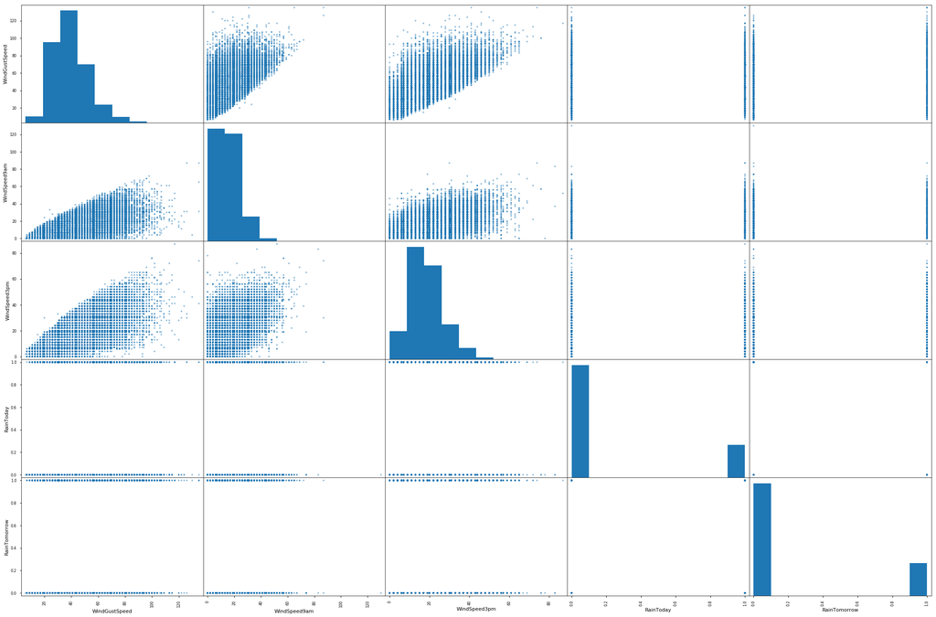

```python
attributes = ['WindGustSpeed','WindSpeed9am','WindSpeed3pm','RainToday','RainTomorrow']

scatter_matrix(df[attributes], figsize=(36,24))
plt.show()
```

```python
mtxcorr = df.corr()
mtxcorr["WindGustSpeed"].sort_values(ascending=False)
```

```
WindGustSpeed    1.000000
WindSpeed3pm     0.686419
WindSpeed9am     0.604837
RainTomorrow     0.234010
MinTemp          0.177285
RainToday        0.154148
Rainfall         0.133497
Cloud            0.101280
MaxTemp          0.067690
Humidity        -0.066629
Pressure        -0.439830
Name: WindGustSpeed, dtype: float64
```

SI nota che entrambi gli attributi WindSpeed sono abbastanza correlati con WindGustSpeed, il che indica che combinati potrebbero dare WindGustSpeed, dato che quest'ultimo rappresenta il cambio di intesità della velocita del vento durante la giornata. Inoltre WindSpeed3pm e WindSpeed9am, presentano una bassa correlazione con rainTomorrow rispetto a WindGustSpeed, il quale è correlato anche alla pressione. Quindi ho deciso di eliminare queste due colonne, comprese anche le colonne relative alle loro direzioni del vento.

```python
df=df.drop('WindSpeed9am',axis=1)
df=df.drop('WindSpeed3pm',axis=1)
df=df.drop('WindDir9am',axis=1)
df=df.drop('WindDir3pm',axis=1)
df.shape
```

```
(142193, 12)
```

Adesso passo ai dati non categorici, iniziando da data. Inanzitutto controllo fino a dove inizia e fino a dove finisce il periodo di osservazione, controllo anche la presenza di date ripetute.In seguito, la prima analisi statistica che effettuerò riguarda l'andamento generico della piovosità.

```python
df_sort=df.sort_values(by=['Date'],ascending=True)
print("Inizio osservazione: "+str(df_sort['Date'].iloc[0]))
print("Fine osservazione: "+str(df_sort['Date'].iloc[len(df)-1]))
```

```
Inizio osservazione: 2007-11-01
Fine osservazione: 2017-06-25
```

```python
print("Numero giorni (approssimato) di osservazione: "+str((2017-2007)*365-30*5))
```

```
Numero giorni (approssimato) di osservazione: 3500
```

I giorni del periodo di osservazione sono effettivamente minori del numero di entries, quindi probabilmente le date sono al loro volta divise per zona. Ovvero a una dato corrispondono più location. Provo a confermare questa ipotesi.

```python
df_check = df_sort.groupby(['Location'])[['Date']].count()
df_check = df_check.rename({'Date': 'NumGiorniOsservati'}, axis=1)
df_check
```

| Location | NumGiorniOsservati |
| --- | --- |
| Adelaide | 3090 |
| Albany | 3016 |
| Albury | 3011 |
| AliceSprings | 3031 |
| BadgerysCreek | 2928 |
| Ballarat | 3028 |
| Bendigo | 3034 |
| Brisbane | 3161 |
| Cairns | 2988 |
| Canberra | 3418 |
| Cobar | 2988 |
| CoffsHarbour | 2953 |
| Dartmoor | 2943 |
| Darwin | 3192 |
| GoldCoast | 2980 |
| Hobart | 3188 |
| Katherine | 1559 |
| Launceston | 3028 |
| Melbourne | 2435 |
| MelbourneAirport | 3009 |
| Mildura | 3007 |
| Moree | 2854 |
| MountGambier | 3030 |
| MountGinini | 2907 |
| Newcastle | 2955 |
| Nhil | 1569 |
| NorahHead | 2929 |
| NorfolkIsland | 2964 |
| Nuriootpa | 3002 |
| PearceRAAF | 2762 |
| Penrith | 2964 |
| Perth | 3193 |
| PerthAirport | 3009 |
| Portland | 2996 |
| Richmond | 2951 |
| Sale | 3000 |
| SalmonGums | 2955 |
| Sydney | 3337 |
| SydneyAirport | 3005 |
| Townsville | 3033 |
| Tuggeranong | 2998 |
| Uluru | 1521 |
| WaggaWagga | 2976 |
| Walpole | 2819 |
| Watsonia | 2999 |
| Williamtown | 2553 |
| Witchcliffe | 2952 |
| Wollongong | 2983 |
| Woomera | 2990 |

```python
dateTotali=df_check.NumGiorniOsservati.values.sum()
if dateTotali==df['Date'].count():
   print("Ipotesi Confermata!")
else :
   print("Ipotesi Errata!")
```

```
Ipotesi Confermata!
```

La nostra ipotesi è stata confermata, perchè il numero di giorni osservati combiacia più o meno con il numero di giorni che passano nel periodo di osservazione. Alcune località però presentano un numero significativamente più basso di valori di data, il che significa che molte zone, come Uluru,Katherine etc. non hanno riportato la loro osservazione per lunghi periodi.

Siccome non c'è uniformita nel numero di osservazioni, proverò a effettuare delle statistiche in base ai mesi in cui ha piovuto di più, in termini di giorni di pioggia, e i mesi in cui è scesa più pioggia in termini di ml.

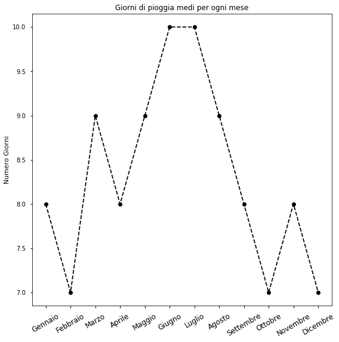

```python
#Faccio una copia del dataset per suddividere la data in mesi
import re
df_copy=df.copy()

mesi=['Gennaio','Febbraio','Marzo','Aprile','Maggio','Giugno','Luglio','Agosto','Settembre','Ottobre','Novembre','Dicembre']

df_copy.Date.replace({'[0-9]+-01-[0-9]+':0,'[0-9]+-02-[0-9]+':1,'[0-9]+-03-[0-9]+':2,'[0-9]+-04-[0-9]+':3,
                     '[0-9]+-05-[0-9]+':4,'[0-9]+-06-[0-9]+':5,'[0-9]+-07-[0-9]+':6,'[0-9]+-08-[0-9]+':7,
                      '[0-9]+-09-[0-9]+':8,'[0-9]+-10-[0-9]+':9,'[0-9]+-11-[0-9]+':10,'[0-9]+-12-[0-9]+':11},
                        regex=True,inplace=True)

df_mesi=df_copy.groupby(['Date'])[['RainToday']].sum()//(30*10)
df_mesi['MediaPioggiaCaduta']=df_copy.groupby(['Date']).mean()['Rainfall']


fig, ax = plt.subplots(1,1)
fig.set_size_inches(9,9)
ax.plot(df_mesi['RainToday'],'ko--')

ax.set_xticks([i for i in range(12) ])
xlabels = ax.set_xticklabels(mesi,rotation=30, fontsize=12)
ax.set_title('Giorni di pioggia medi per ogni mese')
_ = ax.set_ylabel('Numero Giorni')
```

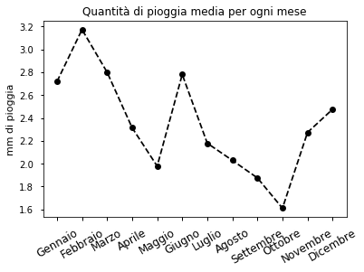

```python
ig, ax = plt.subplots(1,1)
fig.set_size_inches(9,9)
ax.plot(df_mesi['MediaPioggiaCaduta'],'ko--')

ax.set_xticks([i for i in range(12) ])
xlabels = ax.set_xticklabels(mesi,rotation=30, fontsize=12)
ax.set_title('Quantità di pioggia media per ogni mese')
_ = ax.set_ylabel('mm di pioggia')
```

Dato che i periodi di pioggia sono divisi per blocchi di mesi, provo a dividerli per stagioni. In modo da raggruppare i mesi in cui piove di iù in un'unica batch.

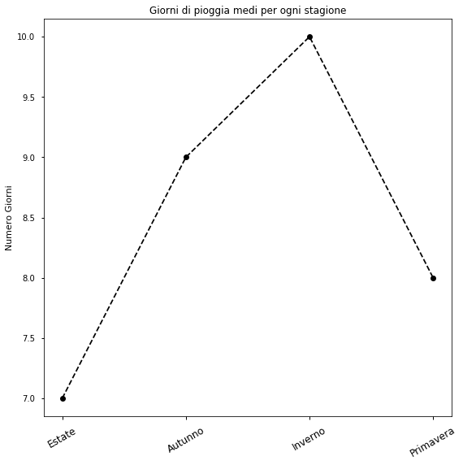

```python
df_copy=df.copy()

stagioni=['Estate','Autunno','Inverno','Primavera']

df_copy.Date.replace({'[0-9]+-(12|0[1-2])-[0-9]+':0,'[0-9]+-0[3-5]-[0-9]+':1,'[0-9]+-0[6-8]-[0-9]+':2,'[0-9]+-(09|1[0-1])-[0-9]+':3},
                      regex=True,inplace=True)

df_stagioni=df_copy.groupby(['Date'])[['RainToday']].sum()//(30*3*10)
df_stagioni['MediaPioggiaCaduta']=df_copy.groupby(['Date']).mean()['Rainfall']


fig, ax = plt.subplots(1,1)
fig.set_size_inches(9,9)
ax.plot(df_stagioni['RainToday'],'ko--')

ax.set_xticks([i for i in range(4) ])
xlabels = ax.set_xticklabels(stagioni,rotation=30, fontsize=12)
ax.set_title('Giorni di pioggia medi per ogni stagione')
_ = ax.set_ylabel('Numero Giorni')
```

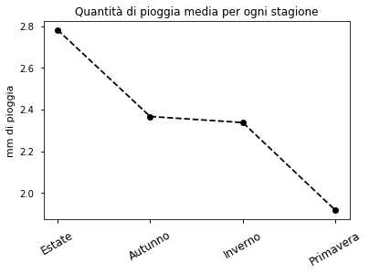

```python
ig, ax = plt.subplots(1,1)
fig.set_size_inches(9,9)
ax.plot(df_stagioni['MediaPioggiaCaduta'],'ko--')

ax.set_xticks([i for i in range(4) ])
xlabels = ax.set_xticklabels(stagioni,rotation=30, fontsize=12)
ax.set_title('Quantità di pioggia media per ogni stagione')
_ = ax.set_ylabel('mm di pioggia')
```

Effettuando la statistica sulle stagioni non abbiamo ottenuto dei dati considerevoli rispetto all'analisi effettuata sui mesi. Anzi adesso ci siamo accorti che non c'è una grossa differenza tra le varie stagioni, i giorni di pioggia medi durante l'anno cambiano di poco. L'unica differenza rigurda l'ammontare di pioggia che cade, d'estate piove di meno in termini di giorni ma di più in termini di mm. Ma tutto ciò non è rilevante per gli obiettivi del nostro tipo di classificazione.

```python
df.Location.unique()
```

```
array(['Albury', 'BadgerysCreek', 'Cobar', 'CoffsHarbour', 'Moree',
       'Newcastle', 'NorahHead', 'NorfolkIsland', 'Penrith', 'Richmond',
       'Sydney', 'SydneyAirport', 'WaggaWagga', 'Williamtown',
       'Wollongong', 'Canberra', 'Tuggeranong', 'MountGinini', 'Ballarat',
       'Bendigo', 'Sale', 'MelbourneAirport', 'Melbourne', 'Mildura',
       'Nhil', 'Portland', 'Watsonia', 'Dartmoor', 'Brisbane', 'Cairns',
       'GoldCoast', 'Townsville', 'Adelaide', 'MountGambier', 'Nuriootpa',
       'Woomera', 'Albany', 'Witchcliffe', 'PearceRAAF', 'PerthAirport',
       'Perth', 'SalmonGums', 'Walpole', 'Hobart', 'Launceston',
       'AliceSprings', 'Darwin', 'Katherine', 'Uluru'], dtype=object)
```

Tutte queste zone andando a controllare su internet, fanno parte della zona del sud est dell'australia. COnsiderando che copre solo quella zona e che in alcune località mancano parecchie date, si è deciso di eliminare le località, perchè potrebbero causare overffitting, basare del training su di esse. Dato che nel momento in cui uscisse una nuova zona potrebbe essere falsata la classificazione, se si basa sull'attributo della location. Inoltre vorrei droppare anche le date, perchè, come visto dai grafici, in termine di piovosità non c'è molta differenza tra le varie stagioni o mesi. Infine, molte di esse presentano dei valori mancanti, quindi alcune statistiche sono falsate.

```python
df=df.drop('Location',axis=1)
df=df.drop('Date',axis=1)
df.shape
```

```
(142193, 10)
```

Ultimo controllo sull'attributo Wind Gust Direction.

```python
df.WindGustDir.unique()
```

```
array(['W', 'WNW', 'WSW', 'NE', 'NNW', 'N', 'NNE', 'SW', 'ENE', 'SSE',
       'S', 'NW', 'SE', 'ESE', nan, 'E', 'SSW'], dtype=object)
```

```python
df_Dir = df.groupby(['WindGustDir', 'RainTomorrow'])[['WindGustSpeed']].count()
df_Dir = df_Dir.rename({'WindGustSpeed': 'count'}, axis=1)
df_Dir['prob'] = df_Dir['count'] / df.groupby('WindGustDir').count()['RainTomorrow']
df_Dir
```

| WindGustDir | RainTomorrow | count | prob |
| --- | --- | --- | --- |
| E | 0 | 7721 | 0.851174 |
|  | 1 | 1350 | 0.148826 |
| ENE | 0 | 6704 | 0.838839 |
|  | 1 | 1288 | 0.161161 |
| ESE | 0 | 6105 | 0.835729 |
|  | 1 | 1200 | 0.164271 |
| N | 0 | 6581 | 0.728551 |
|  | 1 | 2452 | 0.271449 |
| NE | 0 | 5741 | 0.813173 |
|  | 1 | 1319 | 0.186827 |
| NNE | 0 | 4952 | 0.769781 |
|  | 1 | 1481 | 0.230219 |
| NNW | 0 | 4698 | 0.716049 |
|  | 1 | 1863 | 0.283951 |
| NW | 0 | 5719 | 0.714607 |
|  | 1 | 2284 | 0.285393 |
| S | 0 | 6932 | 0.774612 |
|  | 1 | 2017 | 0.225388 |
| SE | 0 | 7576 | 0.813836 |
|  | 1 | 1733 | 0.186164 |
| SSE | 0 | 7238 | 0.804848 |
|  | 1 | 1755 | 0.195152 |
| SSW | 0 | 6713 | 0.779675 |
|  | 1 | 1897 | 0.220325 |
| SW | 0 | 6993 | 0.794930 |
|  | 1 | 1804 | 0.205070 |
| W | 0 | 7173 | 0.733436 |
|  | 1 | 2607 | 0.266564 |
| WNW | 0 | 5791 | 0.717952 |
|  | 1 | 2275 | 0.282048 |
| WSW | 0 | 6816 | 0.765757 |
|  | 1 | 2085 | 0.234243 |

Valori di probabilità simili un po' per tutti i valori di wind gust direction, in particolare per quelli che procedono nella stessa direzione. Provo a discretizzarli e assegnargli valori numerici, raggruppando ogni valore nella rispettiva direzione cardinale; quindi la discretizzazione viene effettuata considerando come uniche direzioni il Nord,Sud,Est e Ovest.

```python
df.WindGustDir.replace({'N[A-Z]*':0,'E[A-Z]*':1,'S[A-Z]*':2,'W[A-Z]*':3},regex=True,inplace=True)

df_Dir = df.groupby(['WindGustDir', 'RainTomorrow'])[['WindGustSpeed']].count()
df_Dir = df_Dir.rename({'WindGustSpeed': 'count'}, axis=1)
df_Dir['prob'] = df_Dir['count'] / df.groupby('WindGustDir').count()['RainTomorrow']
df_Dir
```

| WindGustDir | RainTomorrow | count | prob |
| --- | --- | --- | --- |
| 0.0 | 0 | 40186 | 0.756115 |
|  | 1 | 12962 | 0.243885 |
| 1.0 | 0 | 28640 | 0.825884 |
|  | 1 | 6038 | 0.174116 |
| 2.0 | 0 | 27454 | 0.778682 |
|  | 1 | 7803 | 0.221318 |
| 3.0 | 0 | 7173 | 0.733436 |
|  | 1 | 2607 | 0.266564 |

Anche in questo caso asumono probabilità simili, prime di vedere se influisce su WindGustSpeed discretizzo tutti gli attributi su cui è possibile farlo. Per capire come discretizzare gli attributi controllo la loro distribuzione nello spazio, per capire se ci sono intervalli che raggrupppano un gran numero di entries.

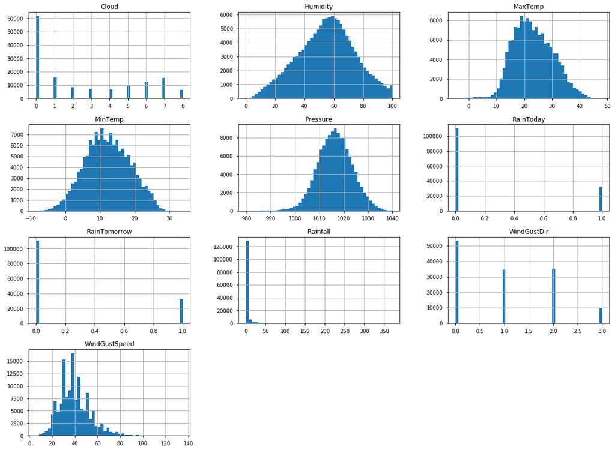

```python
df.hist(bins = 50, figsize = (20,15) )
plt.show()
```

```python
from sklearn.impute import SimpleImputer
from sklearn.pipeline import Pipeline

pipeline = Pipeline([
       ('imputer', SimpleImputer(strategy="median"))])

columns=df.columns
df=pipeline.fit_transform(df)

df=pd.DataFrame(df,columns=columns)
df.RainToday = df.RainToday.astype(int)
df.RainTomorrow = df.RainTomorrow.astype(int)
df.info()
```

```
<class 'pandas.core.frame.DataFrame'>
RangeIndex: 142193 entries, 0 to 142192
Data columns (total 10 columns):
MinTemp          142193 non-null float64
MaxTemp          142193 non-null float64
Rainfall         142193 non-null float64
WindGustDir      142193 non-null float64
WindGustSpeed    142193 non-null float64
Humidity         142193 non-null float64
Pressure         142193 non-null float64
Cloud            142193 non-null float64
RainToday        142193 non-null int64
RainTomorrow     142193 non-null int64
dtypes: float64(8), int64(2)
memory usage: 10.8 MB
```

Adesso discretizzo e verifico che dopo la discretizzazione sia tutto a posto.

```python
df['Pressure'] = pd.cut(df.Pressure, bins = [970., 1000., 1010. ,1020.,1030.,np.inf], labels=[0,1,2,3,4])
tmp = df.groupby(['Pressure', 'RainTomorrow'])[['RainToday']].count()
tmp = tmp.rename({'RainToday':'count'}, axis=1)
tmp['prob'] = tmp['count']/df.groupby('Pressure').count()['RainTomorrow']
tmp
```

| Pressure | RainTomorrow | count | prob |
| --- | --- | --- | --- |
| 0 | 0 | 462 | 0.330709 |
|  | 1 | 935 | 0.669291 |
| 1 | 0 | 12748 | 0.603084 |
|  | 1 | 8390 | 0.396916 |
| 2 | 0 | 63268 | 0.783049 |
|  | 1 | 17529 | 0.216951 |
| 3 | 0 | 30563 | 0.865734 |
|  | 1 | 4740 | 0.134266 |
| 4 | 0 | 3275 | 0.920461 |
|  | 1 | 283 | 0.079539 |

Ottima discretizzazione, più la pressione aumenta, più la probabilità di piovere diminuisce.

```python
df['Humidity'] = pd.cut(df.Humidity, bins = [-0.1, 20., 40. ,60.,80.,np.inf], labels=[0,1,2,3,4])
tmp = df.groupby(['Humidity', 'RainTomorrow'])[['RainToday']].count()
tmp = tmp.rename({'RainToday':'count'}, axis=1)
tmp['prob'] = tmp['count']/df.groupby('Humidity').count()['RainTomorrow']
tmp
```

| Humidity | RainTomorrow | count | prob |
| --- | --- | --- | --- |
| 0 | 0 | 5896 | 0.966241 |
|  | 1 | 206 | 0.033759 |
| 1 | 0 | 23696 | 0.937564 |
|  | 1 | 1578 | 0.062436 |
| 2 | 0 | 47609 | 0.870397 |
|  | 1 | 7089 | 0.129603 |
| 3 | 0 | 29469 | 0.693372 |
|  | 1 | 13032 | 0.306628 |
| 4 | 0 | 3646 | 0.267734 |
|  | 1 | 9972 | 0.732266 |

Qui avviene il contrario, più l'umidità è alta più è probabile che piova.

```python
df['WindGustSpeed'] = pd.cut(df.WindGustSpeed, bins = [0., 20., 35.,40.0 ,60.,80.,np.inf], labels=[0,1,2,3,4,5])
tmp = df.groupby(['WindGustSpeed', 'RainTomorrow'])[['RainToday']].count()
tmp = tmp.rename({'RainToday':'count'}, axis=1)
tmp['prob'] = tmp['count']/df.groupby('WindGustSpeed').count()['RainTomorrow']
tmp
```

| WindGustSpeed | RainTomorrow | count | prob |
| --- | --- | --- | --- |
| 0 | 0 | 6379 | 0.866830 |
|  | 1 | 980 | 0.133170 |
| 1 | 0 | 42677 | 0.849767 |
|  | 1 | 7545 | 0.150233 |
| 2 | 0 | 20375 | 0.788842 |
|  | 1 | 5454 | 0.211158 |
| 3 | 0 | 35515 | 0.735163 |
|  | 1 | 12794 | 0.264837 |
| 4 | 0 | 4808 | 0.525867 |
|  | 1 | 4335 | 0.474133 |
| 5 | 0 | 562 | 0.422239 |
|  | 1 | 769 | 0.577761 |

Adesso controllo meglio Rainfall per capire come discretizzarlo, dato che ha il 50% di valori a 0 (picco elevato).

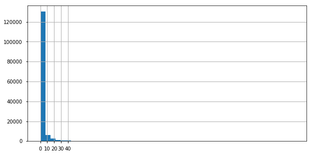

```python
ax=df.Rainfall.hist(bins = 50, figsize = (10,5))
ax.set_xticks([i for i in range(0,50,10) ])
plt.show(fig)
```

```python
df['Rainfall'] = pd.cut(df.Rainfall, bins = [-0.1, 9.,20.,np.inf], labels=[0,1,2])
tmp = df.groupby(['Rainfall', 'RainTomorrow'])[['RainToday']].count()
tmp = tmp.rename({'RainToday':'count'}, axis=1)
tmp['prob'] = tmp['count']/df.groupby('Rainfall').count()['RainTomorrow']
tmp
```

| Rainfall | RainTomorrow | count | prob |
| --- | --- | --- | --- |
| 0 | 0 | 106152 | 0.803610 |
|  | 1 | 25942 | 0.196390 |
| 1 | 0 | 2775 | 0.450707 |
|  | 1 | 3382 | 0.549293 |
| 2 | 0 | 1389 | 0.352359 |
|  | 1 | 2553 | 0.647641 |

Rainfall dopo averlo discretizzato, si è rivelato meglio di quanto pensassi.

```python
df['MaxTemp'] = pd.cut(df.MaxTemp, bins = [-100., 10., 20., 34.,np.inf], labels=[0,1,2,3])
temp = df.groupby(['MaxTemp', 'RainTomorrow'])[['RainToday']].count()
temp = temp.rename({'RainToday':'count'}, axis=1)
temp['prob'] = temp['count']/df.groupby('MaxTemp').count()['RainTomorrow']
temp
```

| MaxTemp | RainTomorrow | count | prob |
| --- | --- | --- | --- |
| 0 | 0 | 1168 | 0.586935 |
|  | 1 | 822 | 0.413065 |
| 1 | 0 | 34990 | 0.703684 |
|  | 1 | 14734 | 0.296316 |
| 2 | 0 | 64825 | 0.810333 |
|  | 1 | 15173 | 0.189667 |
| 3 | 0 | 9333 | 0.890468 |
|  | 1 | 1148 | 0.109532 |

Non piove se la temperatura massima è tra [34,+inf) (90%), dopo i 20° comunque, la probabilità che non piova è circa intorno all'80%.

```python
df['MinTemp'] = pd.cut(df.MinTemp, bins = [-10., 5., 20., np.inf], labels=[0,1,2])
temp = df.groupby(['MinTemp', 'RainTomorrow'])[['RainToday']].count()
temp = temp.rename({'RainToday':'count'}, axis=1)
temp['prob'] = temp['count']/df.groupby('MinTemp').count()['RainTomorrow']
temp
```

| MinTemp | RainTomorrow | count | prob |
| --- | --- | --- | --- |
| 0 | 0 | 16586 | 0.856848 |
|  | 1 | 2771 | 0.143152 |
| 1 | 0 | 81478 | 0.773117 |
|  | 1 | 23911 | 0.226883 |
| 2 | 0 | 12252 | 0.702241 |
|  | 1 | 5195 | 0.297759 |

Non piove se la temperatura minima è tra [-10,5], 85% di probabilità.

La temperatura non sembra molto influente sulla pioggia, ma può essere utile per gli altri attributi. Per verificare che gli attributi scelti fin'ora vanno bene, utilizzo il random forest, per capire se ognuno di essi è fondamentale.

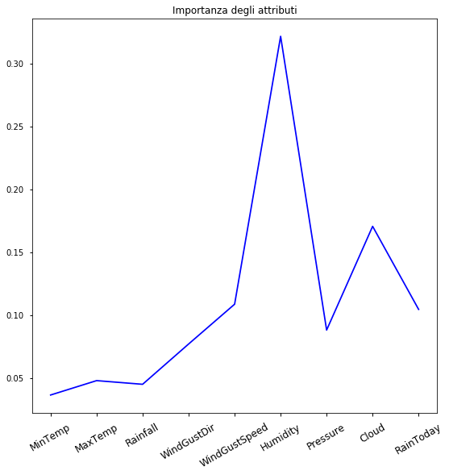

```python
from sklearn.ensemble import RandomForestClassifier

rnd_clf = RandomForestClassifier(n_estimators=500, random_state=42)
df_train=df.copy()
df_train=df_train.drop('RainTomorrow',axis=1)

label=df['RainTomorrow']
rnd_clf.fit(df_train,label)

nameCol=df_train.columns
fig, ax = plt.subplots(1,1)
fig.set_size_inches(9,9)
ax.plot(rnd_clf.feature_importances_,'b-')

ax.set_xticks([i for i in range(len(nameCol))])
xlabels = ax.set_xticklabels(nameCol,rotation=30, fontsize=12)
_=ax.set_title('Importanza degli attributi')
```

```python
for name, score in zip(nameCol, rnd_clf.feature_importances_):
    print(name, score)
```

```
MinTemp 0.03654128581577789
MaxTemp 0.04796711356932938
Rainfall 0.04505249411604063
WindGustDir 0.07706161015934182
WindGustSpeed 0.10868055018171013
Humidity 0.3214894891211597
Pressure 0.08812526434186503
Cloud 0.17053981092630546
RainToday 0.10454238176847007
```

```python
df
```

|  | MinTemp | MaxTemp | Rainfall | WindGustDir | WindGustSpeed | Humidity | Pressure | Cloud | RainToday | RainTomorrow |
| --- | --- | --- | --- | --- | --- | --- | --- | --- | --- | --- |
| 0 | 1 | 2 | 0 | 3.0 | 3 | 1 | 1 | 1.0 | 0 | 0 |
| 1 | 1 | 2 | 0 | 0.0 | 3 | 1 | 1 | 0.0 | 0 | 0 |
| 2 | 1 | 2 | 0 | 2.0 | 3 | 1 | 1 | 1.0 | 0 | 0 |
| 3 | 1 | 2 | 0 | 0.0 | 1 | 1 | 2 | 0.0 | 0 | 0 |
| 4 | 1 | 2 | 0 | 3.0 | 3 | 2 | 1 | 7.0 | 0 | 0 |
| 5 | 1 | 2 | 0 | 0.0 | 3 | 1 | 1 | 0.0 | 0 | 0 |
| 6 | 1 | 2 | 0 | 3.0 | 3 | 1 | 1 | 0.0 | 0 | 0 |
| 7 | 1 | 2 | 0 | 3.0 | 1 | 1 | 2 | 0.0 | 0 | 0 |
| 8 | 1 | 2 | 0 | 0.0 | 4 | 0 | 1 | 0.0 | 0 | 1 |
| 9 | 1 | 2 | 0 | 3.0 | 1 | 1 | 1 | 0.0 | 1 | 0 |
| 10 | 1 | 2 | 0 | 0.0 | 1 | 1 | 2 | 0.0 | 0 | 1 |
| 11 | 1 | 2 | 0 | 0.0 | 1 | 4 | 1 | 8.0 | 1 | 1 |
| 12 | 1 | 1 | 1 | 3.0 | 4 | 4 | 0 | 8.0 | 1 | 1 |
| 13 | 1 | 2 | 0 | 2.0 | 3 | 2 | 1 | 5.0 | 1 | 0 |
| 14 | 1 | 2 | 0 | 0.0 | 3 | 1 | 2 | 0.0 | 0 | 0 |
| 15 | 1 | 2 | 0 | 0.0 | 1 | 3 | 2 | 2.0 | 0 | 1 |
| 16 | 1 | 2 | 1 | 3.0 | 4 | 3 | 1 | 2.0 | 1 | 1 |
| 17 | 1 | 2 | 1 | 1.0 | 3 | 1 | 1 | 1.0 | 1 | 0 |
| 18 | 1 | 2 | 0 | 1.0 | 1 | 1 | 2 | 0.0 | 0 | 0 |
| 19 | 1 | 2 | 0 | 2.0 | 1 | 1 | 2 | 0.0 | 0 | 0 |
| 20 | 1 | 2 | 0 | 0.0 | 3 | 1 | 2 | 0.0 | 0 | 0 |
| 21 | 2 | 2 | 0 | 0.0 | 3 | 1 | 1 | 0.0 | 0 | 0 |
| 22 | 1 | 2 | 0 | 0.0 | 1 | 1 | 1 | 1.0 | 0 | 0 |
| 23 | 1 | 2 | 0 | 3.0 | 3 | 1 | 2 | 0.0 | 0 | 0 |
| 24 | 1 | 2 | 0 | 2.0 | 1 | 1 | 1 | 0.0 | 0 | 0 |
| 25 | 1 | 2 | 0 | 2.0 | 3 | 1 | 1 | 0.0 | 0 | 0 |
| 26 | 2 | 2 | 0 | 0.0 | 3 | 1 | 1 | 0.0 | 0 | 0 |
| 27 | 1 | 2 | 0 | 0.0 | 3 | 1 | 1 | 0.0 | 0 | 1 |
| 28 | 1 | 2 | 0 | 0.0 | 3 | 3 | 1 | 8.0 | 1 | 0 |
| 29 | 1 | 2 | 0 | 3.0 | 2 | 1 | 1 | 0.0 | 0 | 0 |
| ... | ... | ... | ... | ... | ... | ... | ... | ... | ... | ... |
| 142163 | 1 | 2 | 0 | 0.0 | 2 | 1 | 2 | 6.0 | 0 | 0 |
| 142164 | 1 | 2 | 0 | 3.0 | 1 | 0 | 2 | 0.0 | 0 | 0 |
| 142165 | 1 | 2 | 0 | 1.0 | 1 | 1 | 3 | 0.0 | 0 | 0 |
| 142166 | 1 | 2 | 0 | 1.0 | 2 | 1 | 3 | 8.0 | 0 | 0 |
| 142167 | 1 | 2 | 0 | 1.0 | 1 | 1 | 3 | 4.0 | 0 | 0 |
| 142168 | 1 | 2 | 0 | 1.0 | 3 | 1 | 3 | 0.0 | 0 | 0 |
| 142169 | 1 | 1 | 0 | 1.0 | 3 | 1 | 3 | 0.0 | 0 | 0 |
| 142170 | 0 | 1 | 0 | 1.0 | 2 | 1 | 3 | 0.0 | 0 | 0 |
| 142171 | 0 | 1 | 0 | 0.0 | 2 | 1 | 3 | 0.0 | 0 | 0 |
| 142172 | 0 | 1 | 0 | 1.0 | 1 | 1 | 3 | 0.0 | 0 | 0 |
| 142173 | 0 | 2 | 0 | 1.0 | 2 | 0 | 3 | 0.0 | 0 | 0 |
| 142174 | 0 | 2 | 0 | 1.0 | 3 | 0 | 3 | 0.0 | 0 | 0 |
| 142175 | 0 | 2 | 0 | 1.0 | 3 | 1 | 3 | 0.0 | 0 | 0 |
| 142176 | 0 | 1 | 0 | 1.0 | 2 | 1 | 3 | 0.0 | 0 | 0 |
| 142177 | 0 | 1 | 0 | 1.0 | 3 | 1 | 3 | 0.0 | 0 | 0 |
| 142178 | 0 | 1 | 0 | 1.0 | 3 | 1 | 3 | 0.0 | 0 | 0 |
| 142179 | 0 | 1 | 0 | 1.0 | 1 | 1 | 3 | 0.0 | 0 | 0 |
| 142180 | 1 | 1 | 0 | 1.0 | 3 | 1 | 3 | 0.0 | 0 | 0 |
| 142181 | 0 | 2 | 0 | 0.0 | 1 | 1 | 3 | 0.0 | 0 | 0 |
| 142182 | 0 | 2 | 0 | 1.0 | 1 | 1 | 3 | 0.0 | 0 | 0 |
| 142183 | 0 | 2 | 0 | 2.0 | 0 | 1 | 3 | 0.0 | 0 | 0 |
| 142184 | 1 | 2 | 0 | 1.0 | 1 | 1 | 3 | 0.0 | 0 | 0 |
| 142185 | 1 | 2 | 0 | 1.0 | 1 | 1 | 3 | 0.0 | 0 | 0 |
| 142186 | 1 | 2 | 0 | 1.0 | 3 | 1 | 3 | 5.0 | 0 | 0 |
| 142187 | 1 | 2 | 0 | 1.0 | 1 | 1 | 3 | 0.0 | 0 | 0 |
| 142188 | 0 | 2 | 0 | 1.0 | 1 | 1 | 3 | 0.0 | 0 | 0 |
| 142189 | 0 | 2 | 0 | 1.0 | 1 | 1 | 3 | 0.0 | 0 | 0 |
| 142190 | 0 | 2 | 0 | 0.0 | 1 | 1 | 3 | 0.0 | 0 | 0 |
| 142191 | 1 | 2 | 0 | 0.0 | 2 | 1 | 2 | 0.0 | 0 | 0 |
| 142192 | 1 | 2 | 0 | 1.0 | 1 | 1 | 2 | 2.0 | 0 | 0 |

142193 rows × 10 columns

Una volta ottenuti i nostri attributi di riferimento, possiamo considerare concluso il preprocessing. L'ultimo passo è quello di dividere il test set dal train set, mantenendo in percentuale la stessa distribuzione di valori, considerando l'attributo sul quale effettueremo la classificazione, ovvero RainTomorrow. Con scikitleran divido il dataset in train e test e controllo se la divisione rispecchia i parametri citati qui sopra.

```python
from sklearn.model_selection import train_test_split

training_set, test_set = train_test_split(df, test_size=0.2, random_state=42)
```

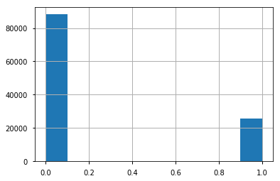

```python
training_set["RainTomorrow"].hist()
```

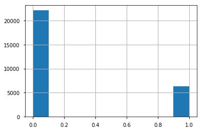

```python
test_set["RainTomorrow"].hist()
```

Split perfetto! Adesso creo le label

```python
training_label=training_set['RainTomorrow'].copy()
training_set=training_set.drop("RainTomorrow",axis=1)
test_label=test_set['RainTomorrow'].copy()
test_set=test_set.drop('RainTomorrow',axis=1)
```

**RETE NEURALE**

```python
from keras.utils import to_categorical

test_label2=test_label.copy()

#one-hot encode labels
training_label=to_categorical(training_label)
test_label=to_categorical(test_label)
```

```python
import keras

modello=keras.Sequential()
modello.add(keras.layers.Dense(units=4,activation='relu',input_shape=(9,)))
modello.add(keras.layers.Dense(units=4,activation='relu'))
modello.add(keras.layers.Dense(units=2,activation='softmax'))

epoche=100
learning_rate=0.01
batch=1024

modello.compile(optimizer=keras.optimizers.SGD(learning_rate),
                    loss='categorical_crossentropy',
                    metrics=['accuracy']
                    )

history=modello.fit(training_set,training_label, validation_data=(test_set, test_label),epochs=epoche,batch_size=batch)
```

[output not shown]

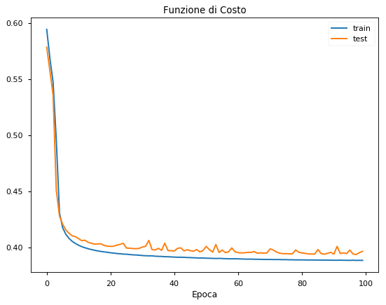

```python
plt.figure(num=None, figsize=(8, 6), dpi=80)
plt.title('Funzione di Costo')
plt.plot(history.history['loss'], label='train')
plt.plot(history.history['val_loss'], label='test')
plt.xlabel('Epoca')
plt.legend()
plt.show()
```

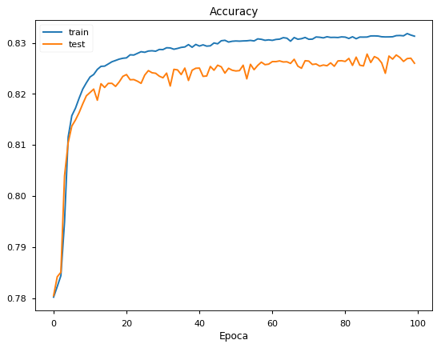

```python
plt.figure(num=None, figsize=(8, 6), dpi=80)
plt.title('Accuracy')
plt.plot(history.history['acc'], label='train')
plt.plot(history.history['val_acc'], label='test')
plt.xlabel('Epoca')
plt.legend()
plt.show()
```

```python
from sklearn.metrics import accuracy_score
from sklearn.metrics import precision_score
from sklearn.metrics import recall_score
from sklearn.metrics import f1_score


y_classes = modello.predict_classes(test_set, verbose=0)

accuracy = accuracy_score(test_label2, y_classes)
print('Accuracy: %f' % accuracy)
precision = precision_score(test_label2, y_classes)
print('Precision: %f' % precision)
recall = recall_score(test_label2, y_classes)
print('Recall: %f' % recall)
f1 = f1_score(test_label2, y_classes)
print('F1 score: %f' % f1)
```

```
Accuracy: 0.826014
Precision: 0.642638
Recall: 0.494875
F1 score: 0.559159
```

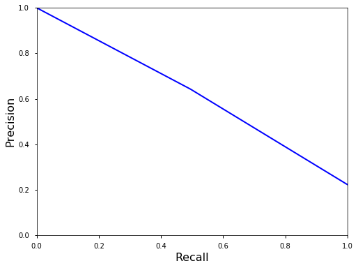

```python
from sklearn.metrics import precision_recall_curve

precisions, recalls, thresholds = precision_recall_curve(test_label2, y_classes)

plt.figure(figsize=(8, 6))
plt.plot(recalls, precisions, "b-", linewidth=2)
plt.xlabel("Recall", fontsize=16)
plt.ylabel("Precision", fontsize=16)
plt.axis([0, 1, 0, 1])

plt.show()
```

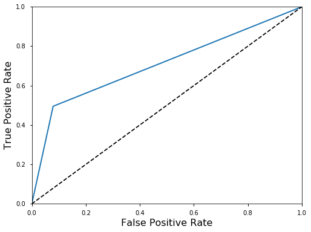

```python
from sklearn.metrics import roc_curve

fpr, tpr, thresholds = roc_curve(test_label2, y_classes)
plt.figure(figsize=(8, 6))
plt.plot(fpr, tpr, linewidth=2, label=label)
plt.plot([0, 1], [0, 1], 'k--')
plt.axis([0, 1, 0, 1])
plt.xlabel('False Positive Rate', fontsize=16)
plt.ylabel('True Positive Rate', fontsize=16)

plt.show()
```

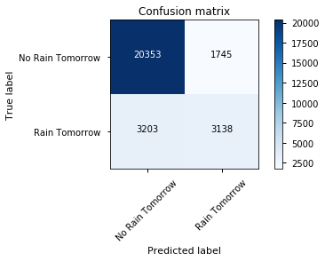

```python
from sklearn.metrics import confusion_matrix
import itertools

def plot_confusion_matrix(cm, classes, normalize=False, title='Confusion matrix', cmap=plt.cm.Blues):

    plt.imshow(cm, interpolation='nearest', cmap=cmap)
    plt.title(title)
    plt.colorbar()
    tick_marks = np.arange(len(classes))
    plt.xticks(tick_marks, classes, rotation=45)
    plt.yticks(tick_marks, classes)

    fmt ='d'
    thresh = cm.max() / 2.
    for i, j in itertools.product(range(cm.shape[0]), range(cm.shape[1])):
        plt.text(j, i, format(cm[i, j], fmt),
                 horizontalalignment="center",
                 color="white" if cm[i, j] > thresh else "black")

    plt.tight_layout()
    plt.ylabel('True label')
    plt.xlabel('Predicted label')
    plt.show()


confusion = confusion_matrix(test_label2, y_classes)
plot_confusion_matrix(confusion, classes=['No Rain Tomorrow', 'Rain Tomorrow'], title='Confusion matrix')
```

```python
output=["No Rain Tomorrow","Rain Tomorrow"]
classe=modello.predict_classes(test_set[0:5], verbose=0)
prob=modello.predict(test_set[0:5],verbose=0)
for p,c in zip(prob,classe):
    print('Classificazione-> Classe: '+output[c]+', Probabilità: %.1f%s' % (p[c]*100,'%'))
```

```
Classificazione-> Classe: Rain Tomorrow, Probabilità: 93.7%
Classificazione-> Classe: No Rain Tomorrow, Probabilità: 74.6%
Classificazione-> Classe: No Rain Tomorrow, Probabilità: 96.7%
Classificazione-> Classe: No Rain Tomorrow, Probabilità: 75.2%
Classificazione-> Classe: No Rain Tomorrow, Probabilità: 76.1%
```

```python
modello.save("rete_neurale.h5")
```

```python
ymod_classes = modello.predict_classes(test_set, verbose=0)
ymod_probs = modello.predict(test_set, verbose=0)


index=0
for classe,prob in zip(ymod_classes,ymod_probs) :
    if classe==0 and (0.50<prob[0]<0.59) :
       ymod_classes[index]=1
       ymod_probs[index,1]=1-ymod_probs[index,1]
    index+=1

accuracy = accuracy_score(test_label2, ymod_classes)
print('Accuracy: %f' % accuracy)
precision = precision_score(test_label2, ymod_classes)
print('Precision: %f' % precision)
recall = recall_score(test_label2, ymod_classes)
print('Recall: %f' % recall)
f1 = f1_score(test_label2, ymod_classes)
print('F1 score: %f' % f1)
```

```
Accuracy: 0.816309
Precision: 0.588050
Recall: 0.588235
F1 score: 0.588143
```

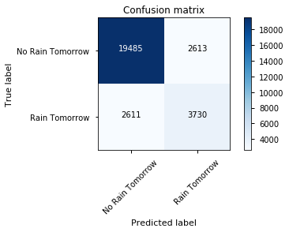

```python
confusion = confusion_matrix(test_label2, ymod_classes)
plot_confusion_matrix(confusion, classes=['No Rain Tomorrow', 'Rain Tomorrow'], title='Confusion matrix')
```